# task1

## Task 1: Introduction

Welcome to **Sentiment Analysis with Keras and TensorFlow**.

[figure not shown]

## Task 2: The IMDB Reviews Dataset

Note: If you are starting the notebook from this task, you can run cells from all previous tasks in the kernel by going to the top menu and then selecting **Kernel > Restart and Run All**

```python
from tensorflow.python.keras.datasets import imdb
(X_train, y_train), (X_test, y_test)= imdb.load_data(num_words= 10000)
#only 10000 words from bag of words will be used and rest will be ignored
```

```python
print(X_train[0])#1st review encoded in a way where each word is represented by a numeric value
#bag of words->all unique words in all reviews ->assign a numeric token which represents that word below
```

```
[1, 14, 22, 16, 43, 530, 973, 1622, 1385, 65, 458, 4468, 66, 3941, 4, 173, 36, 256, 5, 25, 100, 43, 838, 112, 50, 670, 2, 9, 35, 480, 284, 5, 150, 4, 172, 112, 167, 2, 336, 385, 39, 4, 172, 4536, 1111, 17, 546, 38, 13, 447, 4, 192, 50, 16, 6, 147, 2025, 19, 14, 22, 4, 1920, 4613, 469, 4, 22, 71, 87,…
```

```python
print(y_train[0])#0->negative, 1->positive
```

```
1
```

```python
class_names=['Negative' , 'Positive']
```

```python
word_index= imdb.get_word_index()
print(word_index['hello'])
```

```
4822
```

## Task 3: Decoding the Reviews

Note: If you are starting the notebook from this task, you can run cells from all previous tasks in the kernel by going to the top menu and then selecting **Kernel > Restart and Run All**

```python
#just for reference
reverse_word_index= dict((value, key) for key, value in word_index.items())

def decode(review):
    text= ''
    for i in review:
        text += reverse_word_index[i]
        text += ' '
    return text
```

```python
decode(X_train[0])
```

```
"the as you with out themselves powerful lets loves their becomes reaching had journalist of lot from anyone to have after out atmosphere never more room and it so heart shows to years of every never going and help moments or of every chest visual movie except her was several of enough more with is …
```

```python
def show_len():
    print('Length of 1st training example: ', len(X_train[0]))
    print('Length of 1st training example: ', len(X_train[1]))
    print('Length of 1st test example: ', len(X_test[0]))
    print('Length of 1st test example: ', len(X_test[1]))

show_len()
```

```
Length of 1st training example:  218
Length of 1st training example:  189
Length of 1st test example:  68
Length of 1st test example:  260
```

## Task 4: Padding the Examples

Note: If you are starting the notebook from this task, you can run cells from all previous tasks in the kernel by going to the top menu and then selecting **Kernel > Restart and Run All**

```python
word_index['the']
```

```
1
```

```python
from tensorflow.python.keras.preprocessing.sequence import pad_sequences
X_train= pad_sequences(X_train, value= word_index['the'], padding= 'post',
                      maxlen=256)
X_test= pad_sequences(X_test, value= word_index['the'], padding= 'post',
                      maxlen=256)
```

```python
show_len()
```

```
Length of 1st training example:  256
Length of 1st training example:  256
Length of 1st test example:  256
Length of 1st test example:  256
```

```python
decode(X_train[0])
```

```
"the as you with out themselves powerful lets loves their becomes reaching had journalist of lot from anyone to have after out atmosphere never more room and it so heart shows to years of every never going and help moments or of every chest visual movie except her was several of enough more with is …
```

## Task 5: Word Embeddings

Note: If you are starting the notebook from this task, you can run cells from all previous tasks in the kernel by going to the top menu and then selecting **Kernel > Restart and Run All**

Word Embeddings:

[figure not shown]

Feature Vectors:

[figure not shown]

## Task 6: Creating and Training the Model

Note: If you are starting the notebook from this task, you can run cells from all previous tasks in the kernel by going to the top menu and then selecting **Kernel > Restart and Run All**

In one hot encoding algorithm does not understand feature correlation at all. With word embeddings the algorithm can understand related words. Here each word can have a fbunch of different values which will be that word's feature representation.->f.r meanings cannot be understood gemerally by humans but can be imagined as above. Rows represent embeddings.Embeddings are feature representations for various words. Feature representations are learned as we train our model and they become more accurate as we train our model.

```python
from tensorflow.python.keras.models import Sequential
from tensorflow.python.keras.layers import Dense, Embedding, GlobalAveragePooling1D
#embedding- vocab size, size of feature vector
#GAP1D- converts feature representation of (10000,16) to a 16 dimensional vector for each training
#batch and then it can be fed to the Dense layer
#Sigmoid function gives binary classification output
#adam->variant of the stochastic gradient descent, training metric
model= Sequential([Embedding(10000, 16),
                  GlobalAveragePooling1D(),
                  Dense(16, activation='relu'),
                  Dense(1, activation='sigmoid')])
model.compile(loss='binary_crossentropy',
             optimizer='adam',
             metrics= ['accuracy'])
model.summary()
```

```
_________________________________________________________________
Layer (type)                 Output Shape              Param #
=================================================================
embedding_1 (Embedding)      (None, None, 16)          160000
_________________________________________________________________
global_average_pooling1d (Gl (None, 16)                0
_________________________________________________________________
dense (Dense)                (None, 16)                272
_________________________________________________________________
dense_1 (Dense)              (None, 1)                 17
=================================================================
Total params: 160,289
Trainable params: 160,289
Non-trainable params: 0
_________________________________________________________________
```

```python
from tensorflow.python.keras.callbacks import LambdaCallback
simple_log= LambdaCallback(on_epoch_end= lambda e,l: print(e, end='.'))#not complete output to be
#displayed just epoch no. and '.'. Default logging output is not wanted. epoch,log=e,l
E=20

h= model.fit(X_train, y_train, validation_split=0.2, epochs=E, callbacks= [simple_log],
            verbose=False)
```

```
0.1.2.3.4.5.6.7.8.9.10.11.12.13.14.15.16.17.18.19.
```

## Task 7: Predictions and Evaluation

Note: If you are starting the notebook from this task, you can run cells from all previous tasks in the kernel by going to the top menu and then selecting **Kernel > Restart and Run All**

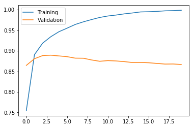

```python
import matplotlib.pyplot as plt
%matplotlib inline

plt.plot(range(E), h.history['acc'], label='Training')
plt.plot(range(E), h.history['val_acc'], label='Validation')
plt.legend()
plt.show()
```

```python
loss, acc= model.evaluate(X_test, y_test)
print('Test Set Accuracy: ',acc*100)
```

```
Test Set Accuracy:  84.26
```

```python
import numpy as np

p= model.predict(np.expand_dims(X_test[0], axis=0))#expand dim if passing 1 example at a time
print(class_names[np.argmax(p[0])])
```

```
Negative
```

```python
decode(X_test[0])
```

```
"the wonder own as by is sequence i i and and to of hollywood br of down shouting getting boring of ever it sadly sadly sadly i i was then does don't close faint after one carry as by are be favourites all family turn in does as three part in another some to be probably with world and her an have fa…
```